# Recommandation de Films avec Edward et Tensorflow

**par**

### Dada Roméo

## Contenu

- **Introduction**
- **Concepts**
- **Implémentation**
- **Résultats**

## Introduction

### Systèmes de Recommandation

(https://www.amazon.com)

[figure not shown]

(https://www.rottentomatoes.com)

[figure not shown]

## Concepts

### Analyse Probabiliste

**Lancé de pièce**

(*face=1, pile=0*)

$obs = [1, 0, 0, 0, 1, 0, 1, 1, 0, 0]$

Quelle est le taux de succès $s$? Où succès équivaut à face.

**Approche simple**

$\begin{align} s & = \frac{2}{5} \\ & = 0.4 \end{align}$

**Approche probabiliste**

(*Thomas Bayes, 1702-1761*)

$P(B \mid A) = \frac{P(A \mid B)P(B)}{P(A)}$

$obs \mid s \sim Bernoulli(s) \\ s \mid obs \ ?$

Suivant Bayes

$\begin{align} Pr(s \mid obs) & = \frac{Pr(obs \mid s)*Pr(s)}{Pr(obs)} \\ & \propto Pr(obs\mid s)*Pr(s) \\ & = Bernoulli(s)*Beta(1,1) \\ & = Beta(5, 7) \end{align}$

```python
from edward.models import Beta
```

[figure not shown]

### Factorisation Matricielle

$\begin{equation} R = \begin{bmatrix} 0 & 0 & 0 & 5 & 2 & 3 \\ 3 & 2 & 4 & 0 & 0 & 0\\ 0 & 3 & 1 & 4 & 0 & 0 \end{bmatrix} \end{equation}$

$R \approx \theta \beta$

où

$R_n^m$, $\theta_n^k$, $\beta_k^m$ et $k \lll m$

$\begin{align} \theta = \begin{bmatrix} \theta_{11} & \theta_{12} \\ \theta_{21} & \theta_{22} \\ \theta_{31} & \theta_{32} \end{bmatrix} ,\qquad \beta = \begin{bmatrix} \beta_{11} &\beta_{12} & \beta_{13} & \beta_{14} & \beta_{15} & \beta_{16} \\ \beta_{21} &\beta_{22} & \beta_{23} & \beta_{24} & \beta_{25} & \beta_{26} \end{bmatrix} \end{align}$

**Approche simple**

$r_{ij} = \theta_i^T\beta_j$

**Approche Probabiliste**

$r_{ij} \sim Poisson(\theta_i^T\beta_j)$

### Hierarchical Poisson Factorization

(*Prem G., Jake M. et David B., 2014*)

1. Pour chaque utilisateur $u$:

   a. Échantillonner l'activité $\xi_u \sim Gamma(a',a'/b')$.

   b. Pour chaque $k$, échantilloner la preférence $\theta_{uk} \sim Gamma(a,\xi_u)$.
1. Pour chaque film $v$:

   a. Échantillonner l'activité $\eta_v \sim Gamma(c',c'/d')$.

   b. Pour chaque $k$, échantillonner l'attribut $\beta_{vk} \sim Gamma(c,\eta)$.
1. Pour chaque utilisateur $u$ et chaque film $v$, échantilloner la note $r_{uv} \sim Poisson(\theta_u^T\beta_v)$.

$\xi, \eta, \theta, \beta \mid R \ ?$

## Implémentation

### Tensorflow

(http://tensorflow.org/)

```python
import tensorflow as tf
```

**Tenseur**

- $3$ - tenseur de dimension $0$ (scalaire)
- $\begin{bmatrix} 3 & 2 \end{bmatrix}$ - tenseur de dimension $1$ (vecteur)
- $\begin{bmatrix} 5 & 4 \\ 2 & 1 \end{bmatrix}$ - tenseur de dimension $2$ (matrice)
- etc...

### Aperçu

```python
a = tf.ones([5])
print(a)
```

```
Tensor("ones:0", shape=(5,), dtype=float32)
```

```python
with tf.Session() as sess:
    print(sess.run(a))
```

```
[ 1.  1.  1.  1.  1.]
```

```python
u = tf.random_normal([3,2])
v = tf.random_normal([2,5])
r = tf.matmul(u, v)
print(r)
```

```
Tensor("MatMul:0", shape=(3, 5), dtype=float32)
```

```python
with tf.Session() as sess:
    print(sess.run(r))
```

```
[[ 1.98479795 -7.53177738 -3.08045149 -0.79195046  5.70455933]
 [ 1.65055919 -4.60123205 -1.12200701  0.604608    2.15609765]
 [ 1.67666364 -4.29715824 -0.81335127  0.90055513  1.60350108]]
```

**Suport carte graphique**

```python
with tf.device("/gpu:0"):
    u = tf.random_normal([3,2])
    v = tf.random_normal([2,5])
    r = tf.matmul(u, v)
```

### Edward

(http://edwardlib.org/)

```python
from edward.models import Poisson, Gamma, PointMass, Empirical
```

```python
from edward.inferences import VariationalInference, MonteCarlo
```

### Spécification du model

```python
k = 20
n_iter = 500
t = 500


act = Gamma(1.0, 1.0, sample_shape=n) # :math:`\xi`
pref = Gamma(1.0, act, sample_shape=k) # :math:`\theta`

pop = Gamma(0.1, 0.1, sample_shape=m) # :math:`\eta`
attr = Gamma(1.0, pop, sample_shape=k) # :math:`\beta`

like = Poisson(tf.gather_nd(tf.matmul(pref, attr, transpose_a=True), idx))


qact = Empirical(
    tf.nn.softplus(tf.Variable(tf.random_normal([t,n]))),
)
qpref = PointMass(
    tf.nn.softplus(tf.Variable(tf.random_normal([k,n]))),
)
qpop = Empirical(
    tf.nn.softplus(tf.Variable(tf.random_normal([t,m]))),
)
qattr = PointMass(
    tf.nn.softplus(tf.Variable(tf.random_normal([k,m]))),
)
```

### Inférence

```python
inference_e = ed.Gibbs(
    {act:qact, pop:qpop},
    data={like:y, pref:qpref, attr:qattr},
)

inference_m = ed.MAP(
    {pref:qpref, attr:qattr},
    data={like:y, act:qact, pop:qpop},
)

inference_e.initialize()
inference_m.initialize(n_iter=n_iter, optimizer="rmsprop")

tf.global_variables_initializer().run()
```

```python
loss = np.empty(n_iter, dtype=np.float32)

for i in range(n_iter):
    info_dict_e = inference_e.update()
    info_dict_m = inference_m.update()

    loss[i] = info_dict_m["loss"]

    inference_m.print_progress(info_dict_m)
```

### Convergence

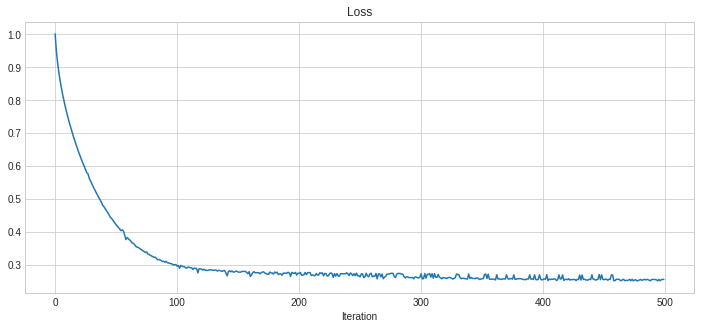

```python
fig = plt.figure(figsize=(12,5))
ax = fig.add_subplot(111)
ax.plot(loss / loss.max())
ax.set_title("Loss")
ax.set_xlabel("Iteration")
```

## Résultalts

### Recommandation

Films que vous avez noté:

[figure not shown]

Films recommandés pour vous:

[figure not shown]

### Similarité

*Toy Story*:

[figure not shown]

Films similaires à *Toy Story*:

[figure not shown]

## Merci!

**Blog**: https://dadaromeo.github.io

**Twitter**: https://twitter.com/dadaromeo

**Code**: https://github.com/dadaromeo/recsys-hpf

**Slides**: https://github.com/dadaromeo/io-extended-douala-2017